# Data Cleaning

loading required library for this project

```r
library(dplyr)
```

```r
library(magrittr)
library(ggplot2)
```

loading the file in escape variable as dataframe

```r
# loading the file
escape <- read.csv('escapes.csv')
```

Checking the dimensions

```r
# Dimensions o dataframes
dim(escape)
```

```
## [1] 357  38
```

the dataset contains of 357 records and 38 features . Now we take a look on summary

```r
# summary of the dataset
summary(escape)
```

```
##    Escape.ID       Operator.at.Time.of.Escape Escape.Water.Type
##  Min.   :2000001   Length:357                 Length:357
##  1st Qu.:2000153   Class :character           Class :character
##  Median :2000295   Mode  :character           Mode  :character
##  Mean   :2000289
##  3rd Qu.:2000417
##  Max.   :2000527
##  Escape.Start.Date  Escape.Start.Time  Escape.End.Time    Escape.Grid.Reference
##  Length:357         Length:357         Length:357         Length:357
##  Class :character   Class :character   Class :character   Class :character
##  Mode  :character   Mode  :character   Mode  :character   Mode  :character
##
##
##
##  Escaped.Species       Stage               Age            Average.Weight
##  Length:357         Length:357         Length:357         Length:357
##  Class :character   Class :character   Class :character   Class :character
##  Mode  :character   Mode  :character   Mode  :character   Mode  :character
##
##
##
##  Initial.Date.of.Escape Initial.Number.Escaped Initial.Escape.Reason
##  Length:357             Length:357             Length:357
##  Class :character       Class :character       Class :character
##  Mode  :character       Mode  :character       Mode  :character
##
##
##
##  Final.Date.of.Escape Final.Number.Escaped Final.Number.Recovered
##  Length:357           Length:357           Length:357
##  Class :character     Class :character     Class :character
##  Mode  :character     Mode  :character     Mode  :character
##
##
##
##  Final.Escape.Reason Marine.Scotland.Site.ID Date.Registered
##  Length:357          Length:357              Length:357
##  Class :character    Class :character        Class :character
##  Mode  :character    Mode  :character        Mode  :character
##
```

[output cut: 22 more lines]

```
##
##   Water.Type        Health.Surveillance    Easting          Northing
##  Length:357         Length:357          Min.   : 75200   Min.   : 580000
##  Class :character   Class :character    1st Qu.:143500   1st Qu.: 733100
##  Mode  :character   Mode  :character    Median :192400   Median : 836500
##                                         Mean   :222677   Mean   : 857400
##                                         3rd Qu.:262000   3rd Qu.: 935500
##                                         Max.   :465700   Max.   :1208200
##  MS.Management.Area    Region            Operator           Species
##  Length:357         Length:357         Length:357         Length:357
##  Class :character   Class :character   Class :character   Class :character
##  Mode  :character   Mode  :character   Mode  :character   Mode  :character
##
##
##
```

I don’t find summary very interesting now explore each feature and broadly figure out which are irrelevant and then delete it as well

## Removing Unneccesay Columns

```r
escape$Aquaculture.Type <- NULL
escape$Escape.End.Time <- NULL
escape$Final.Date.of.Escape <-NULL
escape$Water.Type <- NULL
escape$Site.Address.1 <- NULL
escape$Site.Address.2 <- NULL
escape$Site.Address.3 <- NULL
escape$Escape.Grid.Reference <- NULL
escape$National.Grid.Reference <- NULL
escape$Initial.Number.Escaped <- NULL
escape$Final.Escape.Reason <- NULL
escape$Region <- NULL
escape$Operator <- NULL
escape$Initial.Date.of.Escape <- NULL
escape$Site.Contact.Number <- NULL
escape$Easting <-NULL
escape$Northing <- NULL
```

take one column at a time clean and transform it accordingly

Operator at the time of escape

as we can see from evinronment this column is in character type, covert it into factor so that column is ready for lraning

```r
escape$Operator.at.Time.of.Escape <- as.factor(escape$Operator.at.Time.of.Escape)
levels(escape$Operator.at.Time.of.Escape)
```

```
##  [1] "abbey st. bathans trout farm"       "aquascot sea farms ltd"
##  [3] "aquascot sea farms ltd."            "ardvar salmon"
##  [5] "ardvar salmon ltd"                  "ardvar salmon ltd."
##  [7] "balta island seafare ltd"           "caledonian trout co"
##  [9] "caledonian trout company"           "cloan hatcheries"
## [11] "cloan hatcheries ltd."              "college mill trout farm"
## [13] "cooke aquaculture scotland ltd"     "cro lax ltd."
## [15] "david m brien"                      "dawnfresh farming ltd"
## [17] "drummond fish farms"                "drummond fish farms ltd."
## [19] "ferramus (ss)"                      "finfish ltd"
## [21] "fjord seafood scotland farming ltd" "grieg seafood shetland ltd"
## [23] "harris fish farming"                "hascosay salmon farms ltd"
## [25] "hebridean smolts ltd"               "heogland salmon"
## [27] "highland fish farms"                "hjaltland seafarms ltd"
## [29] "hoghill trout farm ltd"             "hydro seafoods gsp"
```

[output cut: 25 more lines]

it contain 79 different types of operator at the time of escapes

now let we check null value in this column

```r
sum(is.na(escape$Operator.at.Time.of.Escape))
```

```
## [1] 0
```

As it contains zero null values means this column is clean

Escape Water Type

as this column in character data type, first we need to convert it into factors then check levels and null values

```r
escape$Escape.Water.Type <- as.factor(escape$Escape.Water.Type)
escape$Escape.Water.Type
```

```
##   [1] s s s f f f s s s s f f f s f f s s s s f s s s s f s s s s s s s s s s s
##  [38] s f s s s s s f b f f f s f s s s s s f s f f f s s s s s s f s s s s s f
##  [75] s f s f s s s s s s s s s s s s s s s s f s f s s f f f f s s f s s s f f
## [112] s s s s s s s s s s f s f s s s s s s s s s s s s s s s s f f f s s f f f
## [149] s s s f s s s s f f s s s s f f f f s s s s s s s s s s s f s s s s s s s
## [186] s s s s f f f f f s s s f f f s s f f s s s s s s s s s s s f f s s s s s
## [223] s s s s s s s s s f f f f s f f s s s s s s s s s s s f s s s s s s f s s
## [260] s s s s s s s s s s s s s f s s s s s s f f s s s s s f s s s s s s s s s
## [297] s s s s f s f s s s s s s s s s s s s s s s s f s s f f f s f s s f f s s
## [334] s s f s s f s s s s s s f s s s s s s s s s s s
## Levels: b f s
```

```r
levels(escape$Escape.Water.Type)
```

```
## [1] "b" "f" "s"
```

```r
sum(is.na(escape$Escape.Water.Type))
```

```
## [1] 0
```

as it contain only three type of values and it does not have any null value we can say that this column is also clean

##Escape Start Date

as this column in character data type, first we need to convert it into factors then check levels and null values

```r
escape$Escape.Start.Date <- as.POSIXct(escape$Escape.Start.Date, format="%d-%b-%y", tz="UTC")
escape$Escape.Start.Date
```

```
##   [1] "2014-07-24 UTC" "2010-11-09 UTC" "2003-09-24 UTC" "2020-10-22 UTC"
##   [5] "2012-01-18 UTC" "1999-01-18 UTC" "2011-12-25 UTC" "2006-06-25 UTC"
##   [9] "2009-07-01 UTC" "2004-10-08 UTC" "2010-05-20 UTC" "2005-06-24 UTC"
##  [13] "2008-08-20 UTC" "2002-04-27 UTC" "2007-05-01 UTC" "2013-06-03 UTC"
##  [17] "2000-04-01 UTC" "1998-09-08 UTC" "2007-01-22 UTC" "2007-03-15 UTC"
##  [21] "2007-06-11 UTC" "2004-08-11 UTC" "2018-09-18 UTC" "2017-08-18 UTC"
##  [25] "2019-10-18 UTC" "2005-01-11 UTC" "2008-10-08 UTC" "2005-10-11 UTC"
##  [29] "2010-09-30 UTC" "2011-02-21 UTC" "2002-02-28 UTC" "2003-08-01 UTC"
##  [33] "2002-08-07 UTC" "1999-01-29 UTC" "2005-03-30 UTC" "2002-10-17 UTC"
##  [37] "1999-11-15 UTC" "2019-08-31 UTC" "2013-07-15 UTC" "2013-02-03 UTC"
##  [41] "2019-10-10 UTC" "2006-04-17 UTC" "2014-01-02 UTC" "2004-04-29 UTC"
##  [45] "2010-01-04 UTC" "2006-04-07 UTC" "2009-03-25 UTC" "2017-08-29 UTC"
##  [49] "2002-03-20 UTC" "2005-01-14 UTC" "2008-01-01 UTC" "1995-11-01 UTC"
##  [53] "2009-06-19 UTC" "2016-06-01 UTC" "2005-01-14 UTC" "2000-01-31 UTC"
##  [57] "2008-09-16 UTC" "2000-06-01 UTC" "2000-11-16 UTC" "2006-04-25 UTC"
```

[output cut: 75 more lines]

```r
sum(is.na(escape$Escape.Water.Type))
```

```
## [1] 0
```

also in this column we don’t find any null values and all the date convert to appropriate data type.

##Escape Start Time

```r
escape$Escape.Start.Time
```

```
##   [1] "16:30"    "12:00"    "18:00"    "09:00"    NA         NA
##   [7] NA         "13:15"    "11:00"    "16:40"    NA         "21:00"
##  [13] NA         NA         "unknown"  "pm"       NA         NA
##  [19] "14:00"    "13:00"    "11:00"    "11:00"    "11:00"    NA
##  [25] "10:15"    "12:00"    NA         NA         "12:00"    NA
##  [31] NA         NA         "12:00"    NA         "10:30"    "1430"
##  [37] NA         NA         "15:30"    NA         NA         "14:00"
##  [43] NA         NA         "04:00-0"  "12:00"    NA         "overnig"
##  [49] NA         "15:30"    NA         NA         "14:30"    "10:00"
##  [55] "pm"       NA         NA         NA         NA         "09:00"
##  [61] "1200"     NA         NA         "11:00"    "14:00"    "10:00am"
##  [67] NA         NA         "10:10"    NA         "10:45"    "unknown"
##  [73] NA         NA         NA         "17:00"    NA         NA
##  [79] "07:00"    "14:30"    NA         NA         NA         "08:00"
##  [85] "12:30"    NA         "not pro"  "13"       "1700"     "overnig"
```

[output cut: 45 more lines]

as we can see there are several values which does not state time

```r
escape$Escape.Start.Time <- as.factor(escape$Escape.Start.Time)
escape$Escape.Start.Time
```

```
##   [1] 16:30    12:00    18:00    09:00    <NA>     <NA>     <NA>     13:15
##   [9] 11:00    16:40    <NA>     21:00    <NA>     <NA>     unknown  pm
##  [17] <NA>     <NA>     14:00    13:00    11:00    11:00    11:00    <NA>
##  [25] 10:15    12:00    <NA>     <NA>     12:00    <NA>     <NA>     <NA>
##  [33] 12:00    <NA>     10:30    1430     <NA>     <NA>     15:30    <NA>
##  [41] <NA>     14:00    <NA>     <NA>     04:00-0  12:00    <NA>     overnig
##  [49] <NA>     15:30    <NA>     <NA>     14:30    10:00    pm       <NA>
##  [57] <NA>     <NA>     <NA>     09:00    1200     <NA>     <NA>     11:00
##  [65] 14:00    10:00am  <NA>     <NA>     10:10    <NA>     10:45    unknown
##  [73] <NA>     <NA>     <NA>     17:00    <NA>     <NA>     07:00    14:30
##  [81] <NA>     <NA>     <NA>     08:00    12:30    <NA>     not pro  13
##  [89] 1700     overnig  unknown  10:00    overnig  <NA>     <NA>     15:00
##  [97] 14:30    10:00    08:15    <NA>     unknown  <NA>     <NA>     03:00
## [105] <NA>     <NA>     11:00    <NA>     16:00    <NA>     <NA>     09:00
## [113] <NA>     <NA>     <NA>     18:00    <NA>     09:00    <NA>     <NA>
```

[output cut: 31 more lines]

```r
print('------')
```

```
## [1] "------"
```

```r
levels(escape$Escape.Start.Time)
```

```
##  [1] "00:00"    "01:00"    "02:00"    "03:00"    "04:00-0"  "06:00"
##  [7] "07:00"    "08:00"    "08:15"    "08:30"    "09:00"    "09:30"
## [13] "09:40"    "09:50"    "10:00"    "10:00 am" "10:00am"  "10:10"
## [19] "10:15"    "10:30"    "10:35"    "10:45"    "1000"     "11"
## [25] "11:00"    "11:00 am" "11:30"    "12:00"    "12:30"    "1200"
## [31] "12pm"     "13"       "13:00"    "13:10"    "13:15"    "13:45"
## [37] "14:00"    "14:30"    "1430"     "15:00"    "15:30"    "15:35"
## [43] "15:40"    "16:00"    "16:30"    "16:40"    "17:00"    "17:00hr"
## [49] "17:30"    "1700"     "18"       "18:00"    "19:00"    "21:00"
## [55] "23:00"    "2pm"      "700"      "8.3"      "8.45"     "800"
## [61] "900"      "early h"  "n/a"      "not kno"  "not pro"  "overnig"
## [67] "pm"       "unknown"
```

```r
#In Escape.start.time, at some places data entered is not in correct form. So we corrected data by assigning right values

escape <- escape %>% mutate(Escape.Start.Time = recode(Escape.Start.Time, "04:00-0" = "04:00", "10:00 am" = "10:00", "10:00am"= "10:00", "1000" = "10:00","11"="11:00", "11:00 am"="11:00","1200"="12:00","12pm"="12:00","13"="13:00","1430"="14:30","17:00hr"="17:00", "1700"="17:00","18"="18:00","2pm" = "14:00","700" = "07:00","8.3"="08:30","8.45"="08:45", "800"="08:00","900"="09:00"))
print("----")
```

```
## [1] "----"
```

```r
levels(escape$Escape.Start.Time)
```

```
##  [1] "00:00"   "01:00"   "02:00"   "03:00"   "04:00"   "06:00"   "07:00"
##  [8] "08:00"   "08:15"   "08:30"   "09:00"   "09:30"   "09:40"   "09:50"
## [15] "10:00"   "10:10"   "10:15"   "10:30"   "10:35"   "10:45"   "11:00"
## [22] "11:30"   "12:00"   "12:30"   "13:00"   "13:10"   "13:15"   "13:45"
## [29] "14:00"   "14:30"   "15:00"   "15:30"   "15:35"   "15:40"   "16:00"
## [36] "16:30"   "16:40"   "17:00"   "17:30"   "18:00"   "19:00"   "21:00"
## [43] "23:00"   "08:45"   "early h" "n/a"     "not kno" "not pro" "overnig"
## [50] "pm"      "unknown"
```

```r
escape <- escape %>% mutate(Escape.Start.Time = recode(Escape.Start.Time,"early h"= "NA","not kno" = "NA", "not pro" = "NA", "overnig"="NA", "pm"="NA","unknown"="NA", "n/a" = "NA"))

levels(escape$Escape.Start.Time)
```

```
##  [1] "00:00" "01:00" "02:00" "03:00" "04:00" "06:00" "07:00" "08:00" "08:15"
## [10] "08:30" "09:00" "09:30" "09:40" "09:50" "10:00" "10:10" "10:15" "10:30"
## [19] "10:35" "10:45" "11:00" "11:30" "12:00" "12:30" "13:00" "13:10" "13:15"
## [28] "13:45" "14:00" "14:30" "15:00" "15:30" "15:35" "15:40" "16:00" "16:30"
## [37] "16:40" "17:00" "17:30" "18:00" "19:00" "21:00" "23:00" "08:45" "NA"
```

Escape Species

```r
# Convert the Escaped.Species column to a factor
escape$Escaped.Species <- as.factor(escape$Escaped.Species)

# Check the levels of the factor variable
levels(escape$Escaped.Species)
```

```
## [1] "atlantic salmon"           "brown trout and sea trout"
## [3] "cod"                       "halibut"
## [5] "lumpsucker"                "rainbow trout"
## [7] "wrasse"
```

Stage

```r
escape$Stage <- as.factor(escape$Stage)
levels(escape$Stage)
```

```
## [1] "broodfish"                       "fish weighing more than 5 grams"
## [3] "grower fish (salmon only)"       "salmon fresh water stages"
```

## Age

```r
clean_age <- function(age) {

  # Convert the age string to lowercase to ensure consistent pattern matching
  age <- tolower(age)


  # Check if the age contains years (e.g., "2 yrs", "2 yrs sw")
  if (grepl("\\d+\\s*yrs?", age)) {

    # Extract the numeric part and multiply by 12 to convert years to months
    age <- as.numeric(gsub("[^0-9.]", "", age)) * 12
  }
  else {

    # Check if the age contains a range (e.g., "7-8 months")
    if (grepl("(\\d+)-(\\d+)\\s*months?", age)) {

      # Remove non-numeric and non-hyphen characters, split by hyphen, and convert to numeric
      nums <- as.numeric(unlist(strsplit(gsub("[^0-9-]", "", age), "-")))
      # Calculate the mean of the range and store it as the age
      age <- mean(nums)

    }
    else {
      # Remove any text following numbers (e.g., "9 months i" -> "9")
      age <- gsub("(\\d+)\\D+", "\\1", age)

      # Replace "s" values with 6 (e.g., "2001 s1", "2000 s1/2" -> "6")
      age <- gsub("\\d+\\s*s[0-9]+(/\\d+)?", "6", age)

      # Replace any remaining non-numeric characters with NA (null value)
      age <- gsub("[^0-9.]+", NA, age)

      # Convert the age string to a numeric value
      age <- as.numeric(age)
    }
  }

  # Return the cleaned age value
  return(age)
}

# Apply the function to the Age column
escape$Age <- sapply(escape$Age, clean_age)


escape$Age[284]<- 36
escape$Age[218]<- 16.5
escape$Age[76] <- NA
escape$Age[93] <- NA
escape$Age[128] <- NA
escape$Age[150] <- NA
escape$Age[339] <- NA


# Replace values greater than 99 with NA
escape$Age[escape$Age > 99] <- NA

# Calculate the average of the non-NA values
avg_age <- mean(escape$Age, na.rm = TRUE)

# Impute the average to the NA values
escape$Age[is.na(escape$Age)] <- avg_age

# Print the updated escape$Age
escape$Age <- round(escape$Age)

print(escape$Age)
```

```
##   [1] 28 18 30  9 11 15 21 12 15 12 18  3 15 15 15 12 15 15 17  1 18 20 11 14  6
##  [26] 15 17  6 18 22 15 15 16 15 11 21 15  9  4 10 15 13 20 24  8 12 12 15 15 10
##  [51] 12 15 17 14 20 15  9 15 15 22  9 17 30 11 15  6 20 12 11 15 24 12 15 36 15
##  [76] 15 15 15 11  5 34 35  3 26 16  7 12 15 16 20  6 13 15 24 15  7 10  8 15 12
## [101] 20 15 15 15 18  9 14 15 10  8 15 19 15 15  2 16 29 11 15 15  4 15 18 15 15
## [126] 24 15 15 10 15  9 15 14 18 24 24 15 12 11 14  5 20 12 18 15 12  6 12 15 15
## [151] 20 22 36 11 15  2 12 15 27 16 13 15 15 12 14 12 15 13 10 17 18 20 15 13 24
## [176]  6  9  7 24 13  6 19 15 12 24 12  9 13  4 14 15 15 13 15 19 15 13 20 15 24
## [201] 28 15  8 14 15 15 15 24 12  9  4 10 11 18 12 12  9 16 15 14 15  9 10 21 15
## [226] 10  9 15 15 20 27 14 13 20  6 20 12 14  7 15 13 13 15 14 15 15 15 18 16 12
## [251] 15  4 10 24  9 12 15 33 15 16 20 15 12 30  9 11 11 13 11 27  6 24 11 24 21
## [276] 19 15  9 15 14  7 13 18 36 48 15  7 15 18  6  9 15  7 13  9  3 20 16 29 15
## [301] 12 17 15 33 15 23 21 13 21 25 22 18 12 15 18 10 23 15 15  3 16 15  6 10 12
## [326] 19 15 14 10 12 12 12 13 15 23 14 15  9 15  8 15  3 15 15 13 13 24 15 15 12
## [351]  8 15 14 18 17 10 15
```

```r
escape$Age[76]
```

```
## [1] 15
```

```r
# Print the cleaned Age column
```

## Average Weight

```r
clean_weight <- function(weight) {

  # Convert the weight string to lowercase to ensure consistent pattern matching
  weight <- tolower(weight)

  # Check if the weight contains kilograms (e.g., "1.0 kg", "4.5 kg")
  if (grepl("\\d+(\\.\\d+)?\\s*kg", weight)) {

    # Remove non-numeric characters, convert to numeric, and multiply by 1000 to convert kg to g
    weight <- as.numeric(gsub("[^0-9.]", "", weight)) * 1000

  } else {

    # Check if the weight contains a range (e.g., "1.8-2.0 kg", "350 - 400 g")
    if (grepl("(\\d+(\\.\\d+)?)-(\\d+(\\.\\d+)?\\s*(kg|g))", weight)) {

      # Remove non-numeric and non-hyphen characters, split by hyphen, and convert to numeric
      nums <- as.numeric(unlist(strsplit(gsub("[^0-9.-]", "", weight), "-")))

      # Check if the range is in kg, and if so, multiply by 1000 to convert to g
      if (grepl("kg", weight)) {
        nums <- nums * 1000
      }

      # Calculate the mid-point of the range and store it as the weight
      weight <- (nums[1] + nums[2]) / 2
    }

    else {
      # Remove any text following numbers (e.g., "199g", "60 g" -> "199", "60")
      weight <- gsub("(\\d+(\\.\\d+)?)\\D+", "\\1", weight)

      # Replace any remaining non-numeric characters with NA (null value)
      weight <- gsub("[^0-9.]+", NA, weight)

      # Convert the weight string to a numeric value
      weight <- as.numeric(weight)
    }
  }

  # Return the cleaned weight value
  return(weight)
}

# Apply the function to the Average.Weight column
escape$Average.Weight <- sapply(escape$Average.Weight, clean_weight)
escape$Average.Weight[10] <- 1900
escape$Average.Weight[49] <- 1825
escape$Average.Weight[54] <- NA
escape$Average.Weight[65] <- NA
escape$Average.Weight[66] <- NA
escape$Average.Weight[76] <- NA
escape$Average.Weight[87] <- NA
escape$Average.Weight[182] <- NA
escape$Average.Weight[247] <- NA
escape$Average.Weight[262] <- NA
escape$Average.Weight[75] <- 1650
escape$Average.Weight[84] <- 3000
escape$Average.Weight[94] <- 4500
escape$Average.Weight[122] <- 1000.125
escape$Average.Weight[166] <- 60
escape$Average.Weight[185] <- 9000
escape$Average.Weight[204] <- 453.60
escape$Average.Weight[229] <- 4500
escape$Average.Weight[245] <- 3200
escape$Average.Weight[284] <- 18500

# Calculate the average of the non-NA values
avg_wgh <- mean(escape$Average.Weight, na.rm = TRUE)

# Impute the average to the NA values
escape$Average.Weight[is.na(escape$Average.Weight)] <- avg_wgh



# Print the cleaned Average.Weight column in grams
escape$Average.Weight <- round(escape$Average.Weight)

escape$Average.Weight
```

```
##   [1]   9000   1000   4500     75     85   3172   2480   3500   3500   1900
##  [11]    300     70 350400   2400   3172    199     60   3100   3300    235
##  [21]    400   4000   2000   3100   1200   3172   4500   1000   3000   5500
##  [31]   3000   3172   2600   1000   2200    950   1000   1400     11   2400
##  [41]   4500   2200   4000   5000     18    100     60     50   1825   2000
##  [51]    350   2500   3700   3172   4500   3172     40   3000     80   2500
##  [61]     15   3300   4500   2800   3172   3172   5200    150   1000   3400
##  [71]   4700   2300    300  10000   1650   3172   2300    100   2400    350
##  [81]   4500   5000   1000   3000   3000   2000   3172   4300   1500   4500
##  [91]   1500   4100    850   4500    500   1000     60     18   2000     75
## [101]    764    200    200   2100   4900    120   4000   2500   2100    190
## [111]   3172   4800    100   6300    175   2000   3900   1400   3172   4100
## [121]    600   1000   3100   3172   2900   3500   5900   1500   2000   4000
## [131]   1600     60   4000   4560   4800   3000    850    850   3000   2289
## [141]     22   3900    390   4000   1000    415     60     30   2500    106
```

[output cut: 21 more lines]

Initial Escape Reason

```r
escape$Initial.Escape.Reason <- as.factor(escape$Initial.Escape.Reason)
levels(escape$Initial.Escape.Reason)
```

```
##  [1] "chafe/ snag - cha"
##  [2] "equipment damage - eqd"
##  [3] "equipment wear and tear - eqw"
##  [4] "flooding - fld"
##  [5] "hole in net - hol"
##  [6] "human error - hum"
##  [7] "inappropriate equipment - eqi"
##  [8] "net failure (not including hole) - net"
##  [9] "net under water - nuw"
## [10] "no actual escape of fish - nes"
## [11] "other - oth"
## [12] "predator - prd"
## [13] "screen failure - scr"
## [14] "transfer pipe failure - trp"
## [15] "unknown - unk"
## [16] "vandalism - van"
## [17] "weather - wth"
```

Final number Escaped

```r
escape$Final.Number.Escaped
```

```
##   [1] "40"                "4,000"             "1"
##   [4] NA                  "3,180"             "2000"
##   [7] "33,755"            "0"                 "1"
##  [10] "200"               "57"                "4,500"
##  [13] "1254"              "19750"             "0"
##  [16] "270"               "1000"              "10000"
##  [19] "0"                 "0"                 "12"
##  [22] "10,000"            "0"                 "216"
##  [25] "none"              "151,821"           "0"
##  [28] "0"                 "100"               "0"
##  [31] "3000"              "50983"             "36"
##  [34] "100 000"           "0"                 "500"
##  [37] "10 000"            "0"                 "~200"
##  [40] "0"                 "23970"             "0"
##  [43] "ca. 150"           "11,300"            "19,879"
```

[output cut: 104 more lines]

```r
# Function to extract numbers from a string
extract_numbers <- function(x) {
  nums <- as.numeric(gsub("[^0-9]", "", x))
  if (length(nums) == 0) {
    return(NA)
  }
  return(nums)
}

escape$Final.Number.Escaped[81] <- 150
escape$Final.Number.Escaped[204] <- 150
escape$Final.Number.Escaped[206] <- 6500
escape$Final.Number.Escaped[220] <- 775
escape$Final.Number.Escaped[230] <- 35
escape$Final.Number.Escaped[331] <- 75000
escape$Final.Number.Escaped[343] <- 7500

# Apply the extract_numbers function to the escape$Final.Number.Escaped column
escape$Final.Number.Escaped <- sapply(escape$Final.Number.Escaped, extract_numbers)

# Replace NA values with 0
escape$Final.Number.Escaped <- replace(escape$Final.Number.Escaped, is.na(escape$Final.Number.Escaped), 0)


# Check the cleaned values
print(escape$Final.Number.Escaped)
```

```
##   [1]      40    4000       1       0    3180    2000   33755       0       1
##  [10]     200      57    4500    1254   19750       0     270    1000   10000
##  [19]       0       0      12   10000       0     216       0  151821       0
##  [28]       0     100       0    3000   50983      36  100000       0     500
##  [37]   10000       0     200       0   23970       0     150   11300   19879
##  [46]     490       0     163    2400  160000       0   20000     621       0
##  [55]   12000       0       0    6000    3000      27    1000       0    5500
##  [64]       4       0       0       0    2500       1    5776    1558       0
##  [73]       0       1   20000  194000  230000   20000       0     100     150
##  [82]    6560   33072       0     223       0       0    2091       0   16000
##  [91]       0   48834       0       0    4000   10400    5000     283       0
## [100]       0    1601       0    7172   16000    7424    1439       1    6900
## [109]    5727     197       0    5500    6000   20000   80000       0      20
## [118]       0   50000       0       0   10000    8859       0   10534  336470
## [127]    9000       0       0    1000  238420     493       0      50   23805
```

[output cut: 25 more lines]

Final number recovered

```r
# apply extract number funcation to get number
escape$Final.Number.Recovered <- sapply(escape$Final.Number.Recovered, extract_numbers)

# assigned appropriate values accordingly by manually cheking
escape$Final.Number.Recovered[142]<- NA
escape$Final.Number.Recovered[216]<- 90
escape$Final.Number.Recovered[250]<- 90
escape$Final.Number.Recovered[287]<- 4869
escape$Final.Number.Recovered[301]<- 90

# Replace NA values with 0
escape$Final.Number.Recovered <- replace(escape$Final.Number.Recovered, is.na(escape$Final.Number.Recovered), 0)


# Check the cleaned values
print(escape$Final.Number.Recovered)
```

```
##   [1]     0     0     0     0     0     0     0     0     0     0     0     0
##  [13]    14     0     0     0     0     0     0     0    12     0     0   150
##  [25]     0  1618     0     0     0     0     0     0     2     0     0     0
##  [37]     0     0     0     0     0     0     0     0   300     0     0     0
##  [49]     0     0  6000     0     0     0     0     0     0     0     0    15
##  [61]   200     0     0     3     0     0     0     0     0     0     0     0
##  [73]     0     1     0 27453     0     0     0     0     0     0     0     0
##  [85]     0     0     0     0     0     0     0     0     0    12     0     0
##  [97]     0     0     0     0     0     0     0     0     0     0     0     0
## [109]     0    44     0     0     0     0     0     0     0     0     0     0
## [121]     0     0     0     0     0     0     0     0     0     0     0     0
## [133]     0    31    15     0     0     0     0     0     0     0     0     0
## [145]    65     0     0     0     0     0     0     7     2  1900     0     0
## [157]     0     0     0     0     0     0     0     0     0     0     0     0
## [169]     0     0   100     0     0     0     0    96     0     0     0     0
## [181]     0     0     0     0     0     0     0     0     0     0     0     0
## [193]     0     0    89     0     0     0     0     0     0     0  2889    16
## [205]     0     0     0     0     0     0     0     0     0     0     0    90
## [217]     0     0     0     0     0  1300     0     0     0     0     0     6
## [229]     0     0     0     0     0     0     0     0     0     0     0     0
## [241]     0     0     0     0     0     0     0     0     0    90     0   600
## [253]     0     0     0     0     1     0     0     0     0     0     0     0
## [265]     0     0     0     0     0     0     0     0  1000     0  2500     0
## [277]     0     0     0     1     0     0     0     0   500     0  4869     0
## [289]     0     0     0     0     0     0     0     0     0     0     0     0
## [301]    90     0     0     0     0     0     0     0     0     0     0     0
## [313]     0     0     0     0     0     0     0     0     0     0     1     0
## [325]     0     0     0    27     0     0   842     0     0     0     0  2800
## [337]     5     0    50    50     0     0     0     0     0     0     0     0
## [349]     0     0     0    22     0     0     0     0     0
```

## Total number of Escaped

new column is created from escape$Final.Number.Escaped - escape$Final.Number.Recovered

```r
escape$Total.number.escaped <- escape$Final.Number.Escaped - escape$Final.Number.Recovered
escape$Total.number.escaped[escape$Total.number.escaped < 0] <- 0
escape$Total.number.escaped
```

```
##   [1]      40    4000       1       0    3180    2000   33755       0       1
##  [10]     200      57    4500    1240   19750       0     270    1000   10000
##  [19]       0       0       0   10000       0      66       0  150203       0
##  [28]       0     100       0    3000   50983      34  100000       0     500
##  [37]   10000       0     200       0   23970       0     150   11300   19579
##  [46]     490       0     163    2400  160000       0   20000     621       0
##  [55]   12000       0       0    6000    3000      12     800       0    5500
##  [64]       1       0       0       0    2500       1    5776    1558       0
##  [73]       0       0   20000  166547  230000   20000       0     100     150
##  [82]    6560   33072       0     223       0       0    2091       0   16000
##  [91]       0   48834       0       0    4000   10400    5000     283       0
## [100]       0    1601       0    7172   16000    7424    1439       1    6900
## [109]    5727     153       0    5500    6000   20000   80000       0      20
## [118]       0   50000       0       0   10000    8859       0   10534  336470
## [127]    9000       0       0    1000  238420     493       0      19   23790
```

[output cut: 25 more lines]

## changing data type for learning

```r
# as the data in this column is cleaned now converting data for learning

# Marine Scotland ID
escape$Marine.Scotland.Site.ID <- as.factor(escape$Marine.Scotland.Site.ID)


escape$Date.Registered <- as.POSIXct(escape$Date.Registered, format="%d-%b-%y", tz="UTC")


escape$Site.Name <- as.factor(escape$Site.Name)

escape$Local.Authority <- as.factor(escape$Local.Authority)
levels(escape$Local.Authority)
```

```
##  [1] "argyll and bute"       "clackmannanshire"      "dumfries and galloway"
##  [4] "highland"              "north ayrshire"        "orkney"
##  [7] "perth and kinross"     "scottish borders"      "shetland"
## [10] "stirling"              "western isles"
```

```r
escape$Producing.in.Last.3.Years <- as.factor(escape$Producing.in.Last.3.Years)
levels(escape$Producing.in.Last.3.Years)
```

```
## [1] "no"  "yes"
```

```r
escape$Site.Post.Code <- as.factor(escape$Site.Post.Code)

escape$Health.Surveillance <- as.factor(escape$Health.Surveillance)
levels(escape$Health.Surveillance)
```

```
## [1] "high"           "low"            "medium"         "not applicable"
```

```r
escape$MS.Management.Area <- as.factor(escape$MS.Management.Area)
levels(escape$MS.Management.Area)
```

```
##  [1] "10b - loch broom"
##  [2] "10c - ewe"
##  [3] "11a - torridon"
##  [4] "11b - sound of raasay, ainort, scalpay"
##  [5] "12a - snizort"
##  [6] "12b - dunvegan"
##  [7] "14a - carron, kishorn, alsh, duich"
##  [8] "14b - hourn"
##  [9] "15b - linnhe, firth of lorne, sound of mull and loch sunart"
## [10] "15c - ailort"
## [11] "16a - tuath, na keal"
## [12] "16c - loch spelve"
## [13] "16d - seil sound to loch craignish"
## [14] "16e - colonsay"
## [15] "18a - loch caolisport"
```

[output cut: 26 more lines]

```r
escape$Species <- as.factor(escape$Species)
levels(escape$Species)
```

```
##  [1] "atlantic salmon"
##  [2] "atlantic salmon, brown trout and sea trout"
##  [3] "atlantic salmon, lumpsucker"
##  [4] "atlantic salmon, lumpsucker, wrasse"
##  [5] "atlantic salmon, wrasse, lumpsucker"
##  [6] "brown trout and sea trout, atlantic salmon"
##  [7] "brown trout and sea trout, common carp (inc. koi & mirror), rainbow trout, tiger trout"
##  [8] "brown trout and sea trout, rainbow trout"
##  [9] "lumpsucker, atlantic salmon"
## [10] "lumpsucker, atlantic salmon, wrasse"
## [11] "lumpsucker, wrasse, atlantic salmon"
## [12] "rainbow trout"
## [13] "rainbow trout, brown trout and sea trout"
## [14] "rainbow trout, brown trout and sea trout, tiger trout"
## [15] "rainbow trout, common carp (inc. koi & mirror), brown trout and sea trout, tiger trout"
## [16] "wrasse, atlantic salmon"
## [17] "wrasse, atlantic salmon, lumpsucker"
## [18] "wrasse, lumpsucker, atlantic salmon"
```

```r
summary(escape)
```

```
##    Escape.ID                       Operator.at.Time.of.Escape Escape.Water.Type
##  Min.   :2000001   marine harvest (scotland) ltd: 59          b:  1
##  1st Qu.:2000153   the scottish salmon company  : 36          f: 85
##  Median :2000295   dawnfresh farming ltd        : 27          s:271
##  Mean   :2000289   scottish sea farms ltd       : 22
##  3rd Qu.:2000417   kames fish farming ltd       : 18
##  Max.   :2000527   grieg seafood shetland ltd   : 17
##                    (Other)                      :178
##  Escape.Start.Date                Escape.Start.Time
##  Min.   :1995-11-01 00:00:00.00   12:00  : 26
##  1st Qu.:2005-01-11 00:00:00.00   NA     : 25
##  Median :2008-11-30 00:00:00.00   10:00  : 18
##  Mean   :2009-09-22 03:45:52.94   11:00  : 15
##  3rd Qu.:2015-01-09 00:00:00.00   09:00  : 11
##  Max.   :2020-12-04 00:00:00.00   (Other): 92
##                                   NA's   :170
##                   Escaped.Species                             Stage
##  atlantic salmon          :277    broodfish                      :  3
##  brown trout and sea trout:  1    fish weighing more than 5 grams: 84
##  cod                      :  1    grower fish (salmon only)      :247
##  halibut                  :  2    salmon fresh water stages      : 23
##  lumpsucker               :  1
##  rainbow trout            : 74
##  wrasse                   :  1
##       Age        Average.Weight                      Initial.Escape.Reason
##  Min.   : 1.00   Min.   :    11   hole in net - hol             :68
##  1st Qu.:12.00   1st Qu.:   500   predator - prd                :65
##  Median :15.00   Median :  2000   human error - hum             :49
##  Mean   :14.88   Mean   :  3172   no actual escape of fish - nes:48
##  3rd Qu.:17.00   3rd Qu.:  3172   weather - wth                 :47
##  Max.   :48.00   Max.   :350400   equipment damage - eqd        :21
##                                   (Other)                       :59
##  Final.Number.Escaped Final.Number.Recovered Marine.Scotland.Site.ID
##  Min.   :      0      Min.   :    0.0        fs0180 :  9
##  1st Qu.:      0      1st Qu.:    0.0        fs0432 :  8
##  Median :    490      Median :    0.0        fs0717 :  8
##  Mean   :  30996      Mean   :  156.5        fs1176 :  8
##  3rd Qu.:   8213      3rd Qu.:    0.0        fs0150 :  6
##  Max.   :7080000      Max.   :27453.0        fs0268 :  6
##                                              (Other):312
```

[output cut: 25 more lines]

```
##  not in a management area                                   : 83
##  15b - linnhe, firth of lorne, sound of mull and loch sunart: 38
##  6a - loch roag                                             : 23
##  8b - central orkney                                        : 15
##  3a - sw shetland mainland                                  : 14
##  (Other)                                                    :155
##  NA's                                                       : 29
##                                 Species    Total.number.escaped
##  atlantic salmon                    : 63   Min.   :      0
##  rainbow trout                      : 61   1st Qu.:      0
##  atlantic salmon, wrasse, lumpsucker: 40   Median :    400
##  atlantic salmon, lumpsucker, wrasse: 34   Mean   :  30871
##  lumpsucker, atlantic salmon, wrasse: 30   3rd Qu.:   8213
##  wrasse, atlantic salmon, lumpsucker: 27   Max.   :7080000
##  (Other)                            :102
```

## Exporting cleaned data in csv file

```r
write.csv(escape, file = "cleaned_data.csv", row.names = FALSE)
```

# EDA

## No of fishes escaped under Operator:

```r
# aggregating data by operator
escaped_by_operator <- aggregate(escape$Total.number.escaped, by = list(Operator = escape$Operator.at.Time.of.Escape), sum)

# creating new df to store information
colnames(escaped_by_operator) <- c("Operator", "Total_Escaped_Fishes")

# sorting in desc order
escaped_by_operator <- escaped_by_operator[order(-escaped_by_operator$Total_Escaped_Fishes),]

# printing output
print(head(escaped_by_operator,10))
```

```
##                         Operator Total_Escaped_Fishes
## 1   abbey st. bathans trout farm              7080000
## 45 marine harvest (scotland) ltd               345042
## 36        lakeland unst seawater               344685
## 56          orkney sea farms ltd               282500
## 14                  cro lax ltd.               254420
## 20                   finfish ltd               230034
## 55      north uist fisheries ltd               214993
## 49     meridian salmon farms ltd               180192
## 51             mowi scotland ltd               171240
## 69          stolt sea farms ltd.               169547
```

- The operator with the highest number of escaped fishes is Abbey St. Bathans Trout Farm, with 7,080,000 escaped fishes.
- Marine Harvest (Scotland) Ltd follows as the second-highest, with 345,042 escaped fishes.
- Lakeland Unst Seawater ranks third, with 344,685 escaped fishes.
- Orkney Sea Farms Ltd comes in fourth, with 282,500 escaped fishes.
- Cro Lax Ltd. is fifth, with 254,420 escaped fishes.

It is important to note that there is a significant difference between the number of escaped fishes for the top operator (Abbey St. Bathans Trout Farm) and the subsequent operators. This may suggest that the top operator experienced one or more major escape incidents compared to the others.

It’s also worth noting that the number of escaped fishes for some operators is relatively low or even zero. This could indicate that these operators have effective escape prevention measures in place, or they haven’t experienced any significant escape incidents. However, it is also possible that the data may not be complete or up to date for these operators.

## What are the average Age of the fishes which escaped

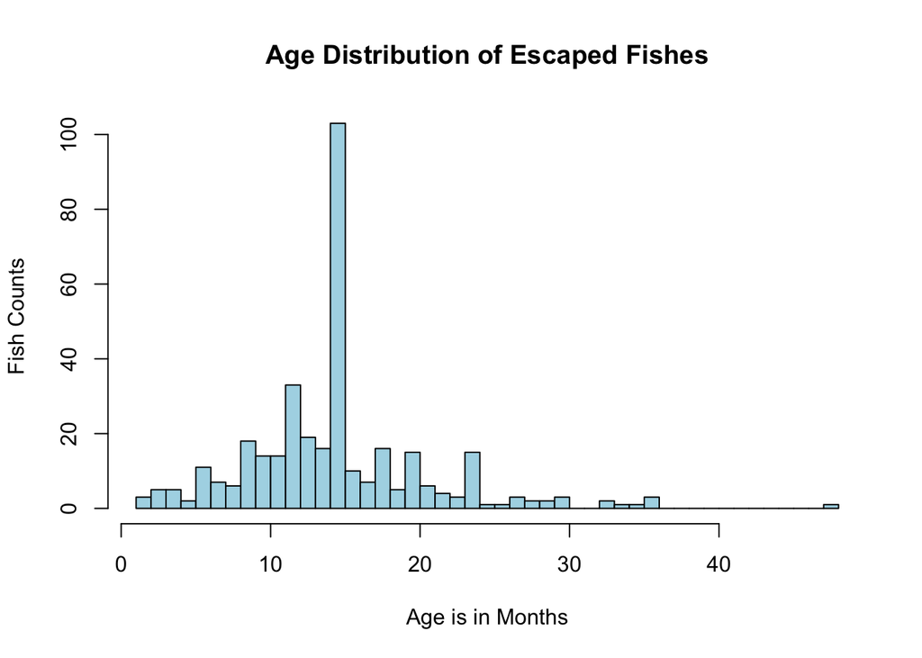

```r
# calulating the average age of the fish
average_age <- mean(escape$Age, na.rm = TRUE)

# ploting visual distributions
hist(escape$Age, main="Age Distribution of Escaped Fishes", xlab="Age is in Months", ylab="Fish Counts", col="lightblue", border="black", breaks = 60)
```

```r
#printing Average Age
print(average_age)
```

```
## [1] 14.88235
```

The average age of the fishes that escaped is approximately 14.88 months. This means that, on average, fishes that escaped from the facilities were around 14.88 months old.

Overall, the histogram reveals that most escaped fishes are between 10 and 20 months old, with a decreasing frequency of escape events as the age of the fishes increases.

## What are the average Weight of the fishes which escaped

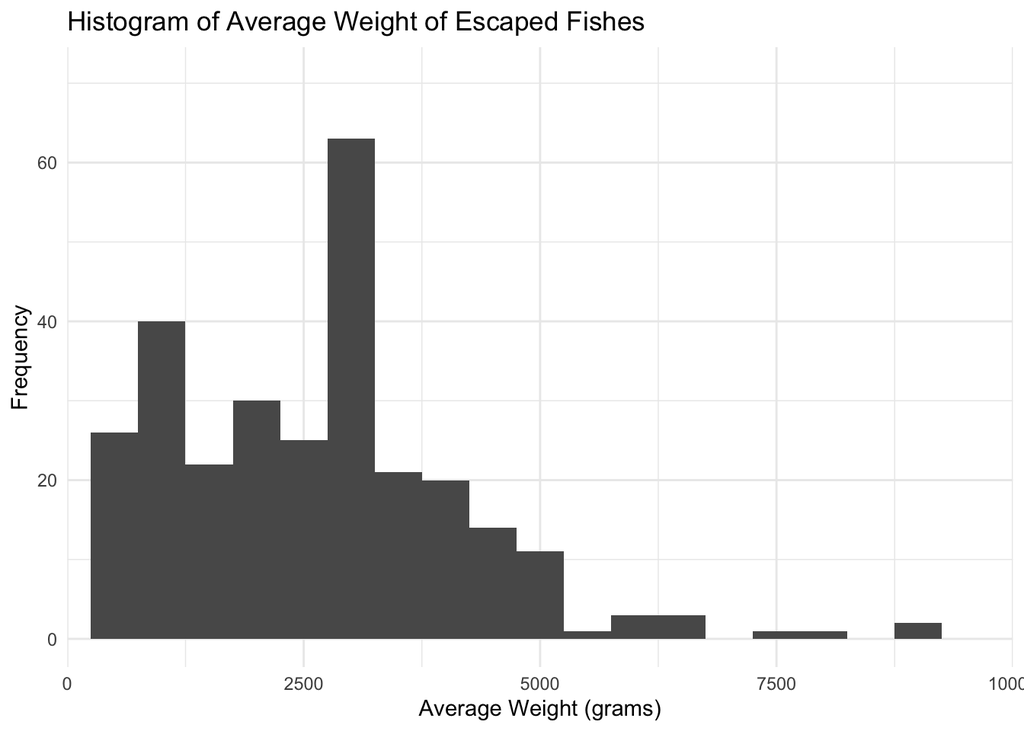

```r
average_weight <- mean(escape$Average.Weight, na.rm = TRUE)


library(ggplot2)

ggplot(escape, aes(x = Average.Weight)) +
  geom_histogram(binwidth = 500) +
  scale_x_continuous(limits = c(0, 10000), expand = c(0, 0)) +
  labs(title = "Histogram of Average Weight of Escaped Fishes", x = "Average Weight (grams)", y = "Frequency") +
  theme_minimal()
```

```r
average_weight
```

```
## [1] 3172.255
```

The average weight of escaped fishes is approximately 3,172.255 grams.

## How does the escape water type affect the number of escapes

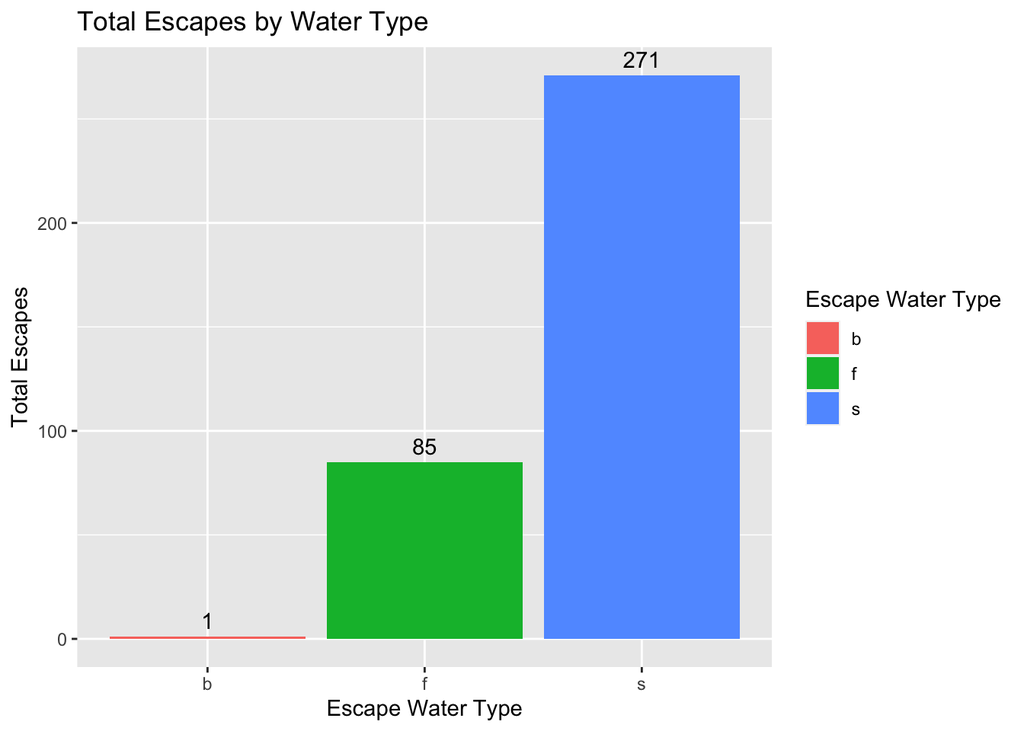

```r
# Count the number of escapes per water type
total_escapes <- aggregate(x = escape$Escape.ID, by = list(Escape.Water.Type = escape$Escape.Water.Type), FUN = length)

# Rename the new column to "Total_Escapes"
colnames(total_escapes)[2] <- "Total_Escapes"

# Sort the dataframe by "Total_Escapes" in descending order
total_escapes <- total_escapes[order(-total_escapes$Total_Escapes),]


# plot in bar chart
ggplot(total_escapes, aes(x = Escape.Water.Type, y = Total_Escapes, fill = Escape.Water.Type)) +
  geom_col() +
  geom_text(aes(label = Total_Escapes), vjust = -0.5) +
  labs(x = "Escape Water Type", y = "Total Escapes", fill = "Escape Water Type") +
  ggtitle("Total Escapes by Water Type")
```

s’ stands for seawater, ‘f’ for freshwater, and ‘b’ for brackish water.

Based on the results:

- Seawater escapes (271 incidents) are the most common, accounting for the majority of escape incidents in the dataset.
- Freshwater escapes (85 incidents) are less frequent but still contribute a significant number of escape incidents.
- Brackish water escapes (1 incident) are very rare, with only a single recorded incident in the dataset.

This suggests that escape incidents are more likely to occur in seawater environments, followed by freshwater environments, and the least likely in brackish water environments.

This is Just A basic EDA performed(answered the basic questions from the data)

# Mering Two DataSet

I cleaned one dataset which named “cleaned_data.csv”, which i will merge with “analysis.csv” on Site.Name

```r
# Load the analysis.csv file into R
analysis <- read.csv("analysis.csv", header = TRUE)

# Convert the Site.Name column of the analysis data frame to lowercase
analysis$Site.Name <- tolower(analysis$Site.Name)

# Merge the escape and analysis data frames based on the Site.Name column
merged_data <- merge(escape, analysis, by = "Site.Name")



# Export the merged_data data frame as a CSV file called "escapesPlus.csv"
write.csv(merged_data, "escapesPlus.csv", row.names = FALSE)

# Confirm that the file was created
file.exists("escapesPlus.csv")
```

```
## [1] TRUE
```